# TS imputation

## Univariate Time Series Missing Value Imputation

### This example is based on the `{imputeTS}` package.

**`tsAirgap` dataset** has 144 rows and the incomplete version includes 13 NA values. It represents the monthly totals of international airline passengers from 1949 to 1960.

#### Visualize the missing values in this time series

```r
class(tsAirgap)
```

```
## [1] "ts"
```

```r
summary(tsAirgap)
```

```
##    Min. 1st Qu.  Median    Mean 3rd Qu.    Max.    NA's
##   104.0   180.5   259.0   279.8   359.5   622.0      13
```

```r
head(tsAirgap,24)
```

```
##      Jan Feb Mar Apr May Jun Jul Aug Sep Oct Nov Dec
## 1949 112 118 132 129  NA 135 148 148  NA 119 104 118
## 1950 115 126 141 135 125 149 170 170  NA 133  NA 140
```

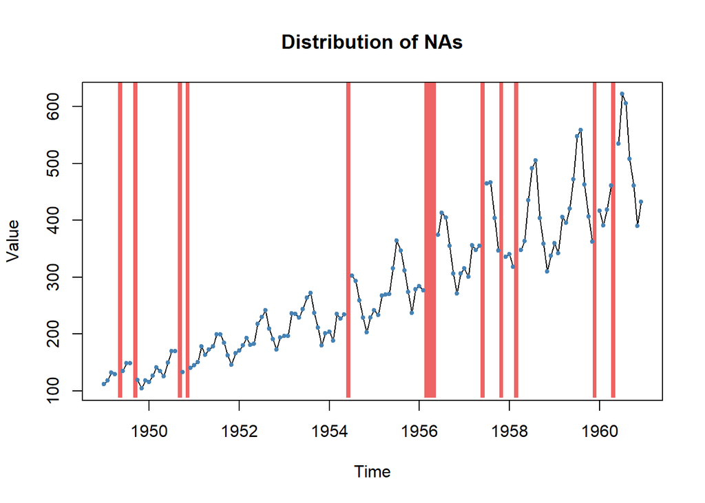

```r
plotNA.distribution(tsAirgap)
```

#### The next plot is especially useful if the time series would otherwise be too large to be plotted.

- Multiple observations for time intervals are grouped together and represented as bars.
- For these intervals, information about the amount of missing values are shown

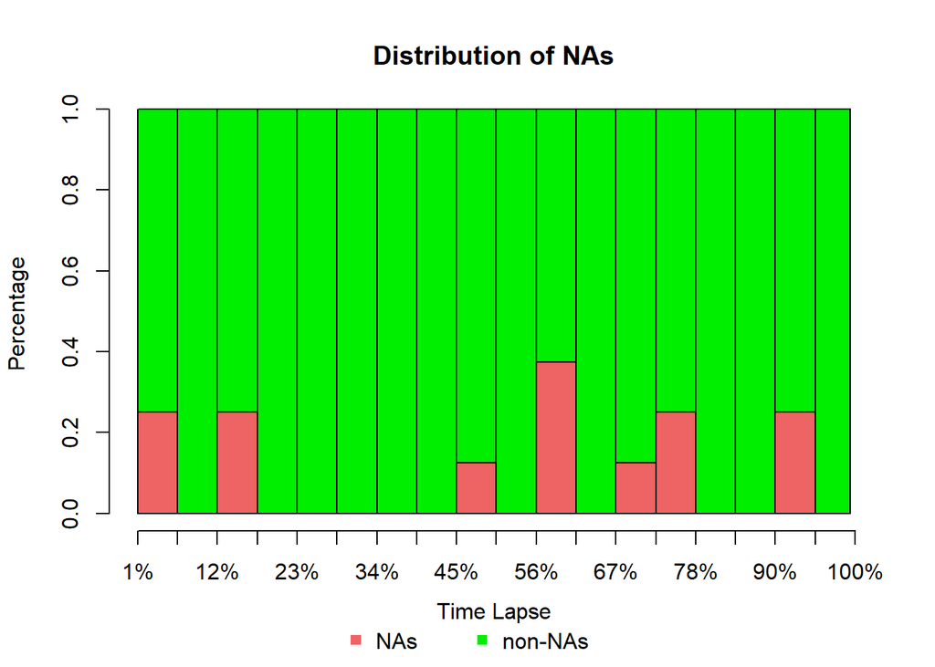

```r
plotNA.distributionBar(tsAirgap, breaks = 20)
```

#### Print stats about the missing data

```r
statsNA(tsAirgap)
```

```
## [1] "Length of time series:"
## [1] 144
## [1] "-------------------------"
## [1] "Number of Missing Values:"
## [1] 13
## [1] "-------------------------"
## [1] "Percentage of Missing Values:"
## [1] "9.03%"
## [1] "-------------------------"
## [1] "Stats for Bins"
## [1] "  Bin 1 (36 values from 1 to 36) :      4 NAs (11.1%)"
## [1] "  Bin 2 (36 values from 37 to 72) :      1 NAs (2.78%)"
## [1] "  Bin 3 (36 values from 73 to 108) :      5 NAs (13.9%)"
## [1] "  Bin 4 (36 values from 109 to 144) :      3 NAs (8.33%)"
## [1] "-------------------------"
## [1] "Longest NA gap (series of consecutive NAs)"
## [1] "3 in a row"
## [1] "-------------------------"
## [1] "Most frequent gap size (series of consecutive NA series)"
## [1] "1 NA in a row (occuring 10 times)"
## [1] "-------------------------"
## [1] "Gap size accounting for most NAs"
## [1] "1 NA in a row (occuring 10 times, making up for overall 10 NAs)"
## [1] "-------------------------"
## [1] "Overview NA series"
## [1] "  1 NA in a row: 10 times"
## [1] "  3 NA in a row: 1 times"
```

### Different types of imputation performed using the `{imputeTS}` package.

#### **Missing value imputation by mean value**

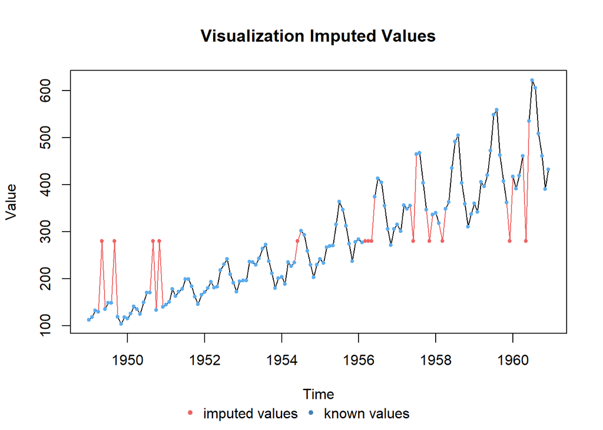

```r
impMean.Airgap <- na_mean(tsAirgap)
plotNA.imputations(tsAirgap, impMean.Airgap)
```

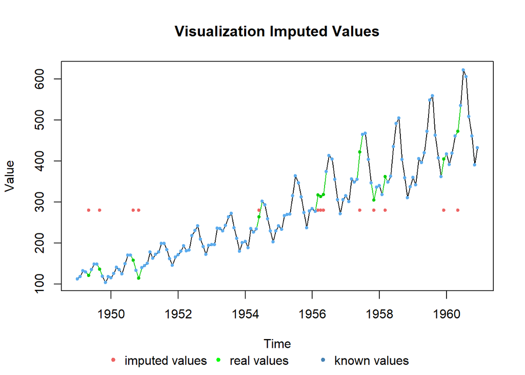

```r
#
#  In this illustrative example, we have the original (full) TS
#  and we can use it to evaluate different imputation methods....
#
plotNA.imputations(tsAirgap, impMean.Airgap, tsAirgapComplete) #  tsAirgapComplete is the complete dataset
```

#### **Imputation by last observation carried forward (LOCF)**

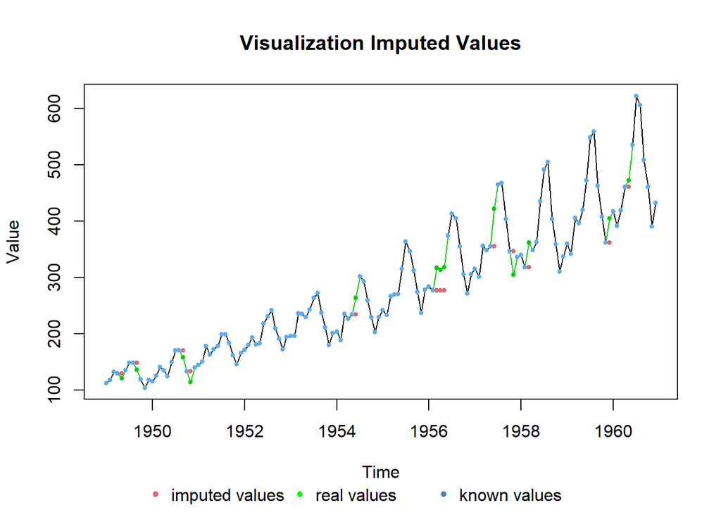

```r
impLOCF.Airgap <- na_locf(tsAirgap)
plotNA.imputations(tsAirgap, impLOCF.Airgap, tsAirgapComplete)
```

#### **Imputation by interpolation: linear & spline**

#### Linear interpolation

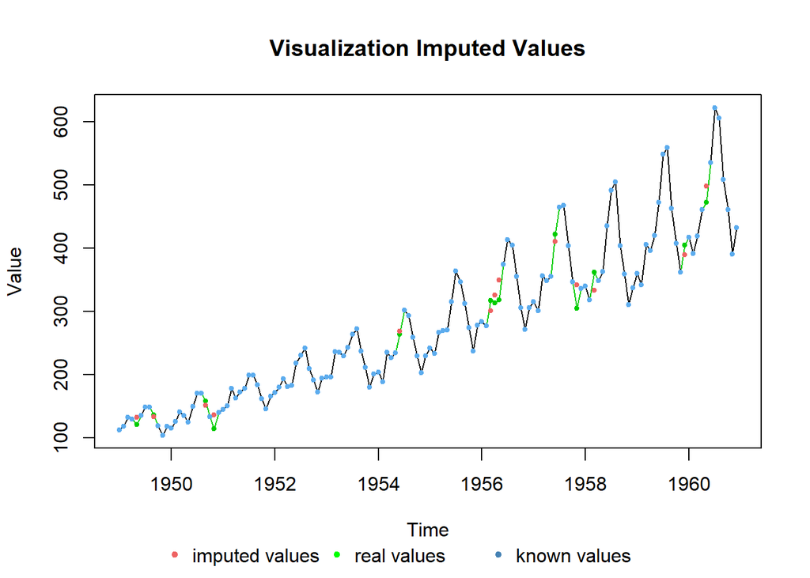

```r
impLinear.Airgap <- na_interpolation(tsAirgap) # Linear interpolation
plotNA.imputations(tsAirgap, impLinear.Airgap, tsAirgapComplete)
```

#### Spline interpolation

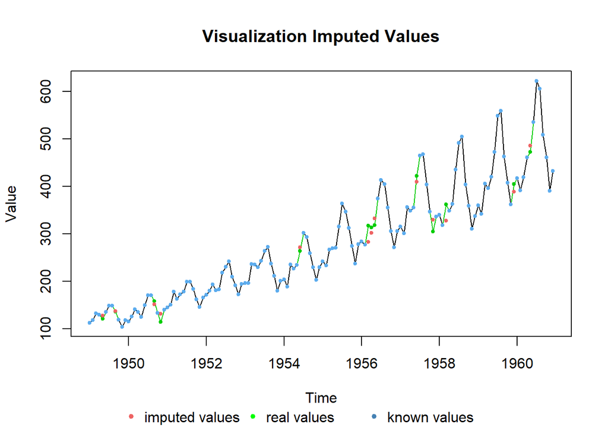

```r
impSpline.Airgap <- na_interpolation(tsAirgap, option = "spline") # Spline interpolation
plotNA.imputations(tsAirgap, impSpline.Airgap, tsAirgapComplete)
```

#### **Kalman filter – for TS with trend & seasonality**

#### Kalman filter

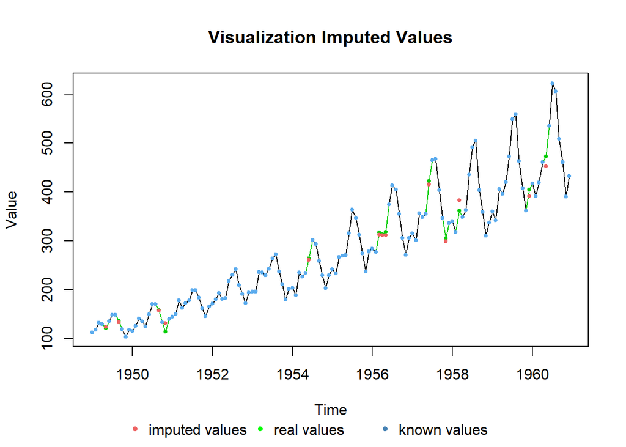

```r
impKalman.Airgap <- na_kalman(tsAirgap, model = "StructTS", smooth = TRUE) # Spline interpolation
plotNA.imputations(tsAirgap, impKalman.Airgap, tsAirgapComplete)
```

## Multivariate Time Series Missing Value Imputation

Package `{Amelia}` supports time series MI:

- We may include time polynomials up to third order as additional variables in the covariance matrix.
- Another option is using time lagged variables (leads, lags).
- Bootstrap approach is used to account for the variance of paramters in a function used to produce imputations.
- For details, see e.g. https://papers.ssrn.com/sol3/papers.cfm?abstract_id=2996611

#### **Amelia – TS example**

```r
library(Amelia)
summary(freetrade)
```

```
##       year        country              tariff           polity
##  Min.   :1981   Length:171         Min.   :  7.10   Min.   :-8.000
##  1st Qu.:1985   Class :character   1st Qu.: 16.30   1st Qu.:-2.000
##  Median :1990   Mode  :character   Median : 25.20   Median : 5.000
##  Mean   :1990                      Mean   : 31.65   Mean   : 2.905
##  3rd Qu.:1995                      3rd Qu.: 40.80   3rd Qu.: 8.000
##  Max.   :1999                      Max.   :100.00   Max.   : 9.000
##                                    NA's   :58       NA's   :2
##       pop                gdp.pc           intresmi          signed
##  Min.   : 14105080   Min.   :  149.5   Min.   :0.9036   Min.   :0.0000
##  1st Qu.: 19676715   1st Qu.:  420.1   1st Qu.:2.2231   1st Qu.:0.0000
##  Median : 52799040   Median :  814.3   Median :3.1815   Median :0.0000
##  Mean   :149904501   Mean   : 1867.3   Mean   :3.3752   Mean   :0.1548
##  3rd Qu.:120888400   3rd Qu.: 2462.9   3rd Qu.:4.4063   3rd Qu.:0.0000
##  Max.   :997515200   Max.   :12086.2   Max.   :7.9346   Max.   :1.0000
##                                        NA's   :13       NA's   :3
##      fiveop          usheg
##  Min.   :12.30   Min.   :0.2558
##  1st Qu.:12.50   1st Qu.:0.2623
##  Median :12.60   Median :0.2756
##  Mean   :12.74   Mean   :0.2764
##  3rd Qu.:13.20   3rd Qu.:0.2887
##  Max.   :13.20   Max.   :0.3083
##  NA's   :18
```

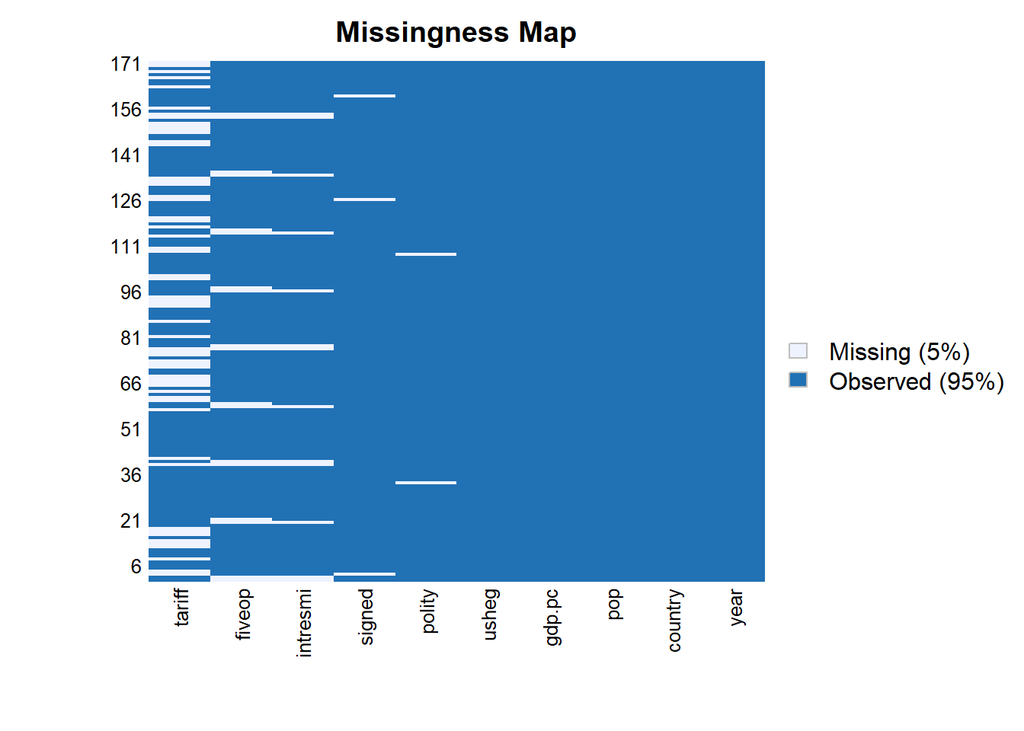

```r
missmap(freetrade) # description of missing data in "freetrade" data
```

- Amelia can build a general model of patterns within variables across time by creating a sequence of polynomials of the time index.
- If, for example, tariffs vary smoothly over time, then we make the modeling assumption that there exists some polynomial that describes the economy in cross-sectional unit $i$ at time $t$ as ($3^{rd} order polynomial is a maximum):
  $$y_{it} = \beta_0 + \beta_1 t + \beta_2 t^2 + \beta_3 t^3 + u_{it}$$

For a second-order polynomial and the `tariff` series, we may do MI as follows:

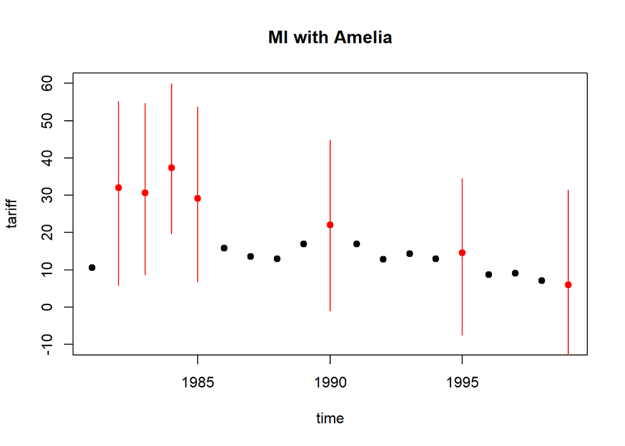

```r
set.seed(100)
a.out <- amelia(freetrade, m=5, ts = "year", cs = "country", polytime = 2, p2s = 0)
tscsPlot(a.out, cs = "Malaysia", main = "MI with Amelia",
         var = "tariff", ylim = c(-10, 60))
```

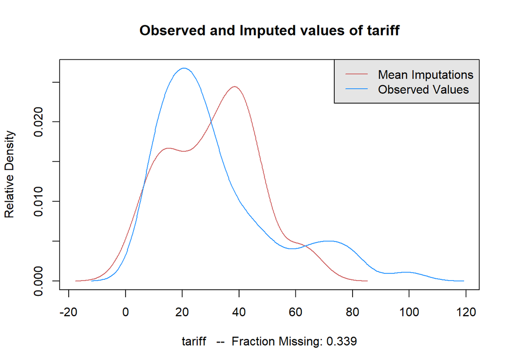

```r
compare.density(a.out, var = "tariff") #not specific to Malaysia
```

```
##
## Amelia output with 5 imputed datasets.
## Return code:  1
## Message:  Normal EM convergence.
##
## Chain Lengths:
## --------------
## Imputation 1:  19
## Imputation 2:  20
## Imputation 3:  18
## Imputation 4:  26
## Imputation 5:  26
##
## Rows after Listwise Deletion:  96
## Rows after Imputation:  171
## Patterns of missingness in the data:  8
##
## Fraction Missing for original variables:
## -----------------------------------------
##
##          Fraction Missing
## year           0.00000000
## country        0.00000000
## tariff         0.33918129
## polity         0.01169591
## pop            0.00000000
## gdp.pc         0.00000000
## intresmi       0.07602339
## signed         0.01754386
## fiveop         0.10526316
## usheg          0.00000000
```

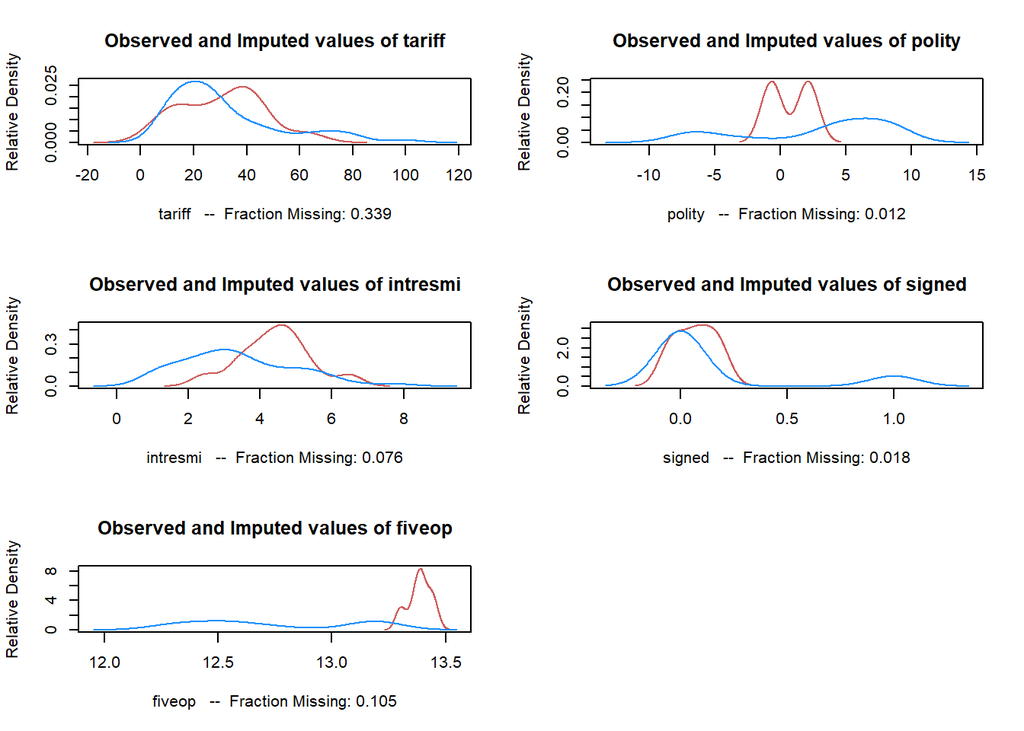

```r
plot(a.out) # overall basic Imputation information plot
summary(a.out)
```

We can also impute with trends specific to each cross-sectional unit:

- `intercs` is a logical argument indicating if the time effects of polytime should vary across the cross-section.

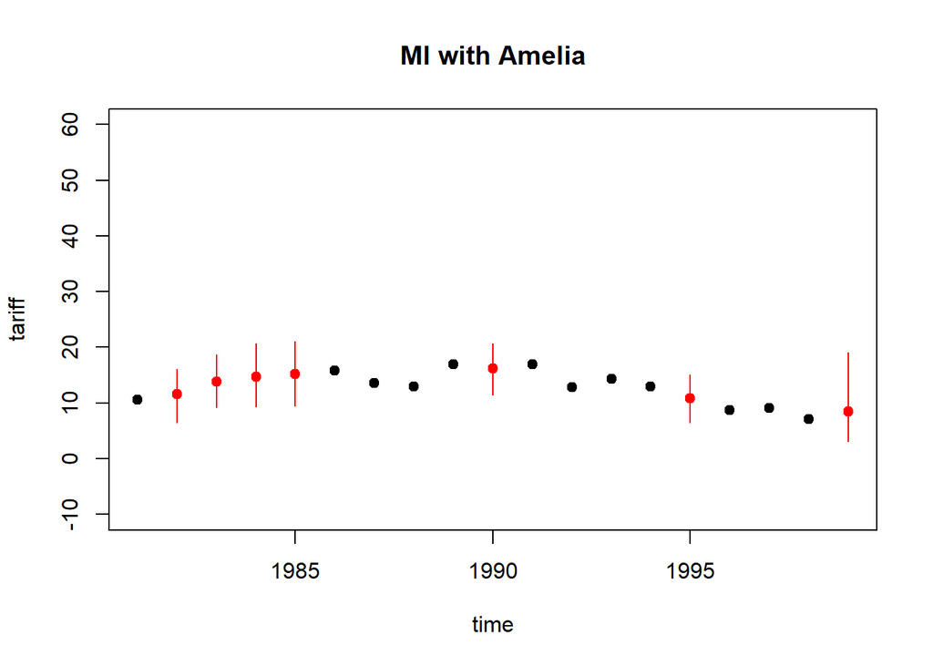

```r
set.seed(120)
a.out.time <- amelia(freetrade, m=5, ts = "year", cs = "country", polytime = 2,
                     intercs = TRUE, p2s = 0) # "p2s = 0" turns off text output
tscsPlot(a.out.time, cs = "Malaysia", main = "MI with Amelia",
         var = "tariff", ylim = c(-10, 60))
```

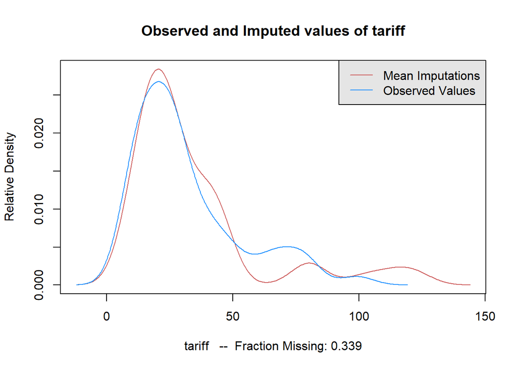

```r
compare.density(a.out.time, var = "tariff") #not specific to Malaysia
```

```
##
## Amelia output with 5 imputed datasets.
## Return code:  1
## Message:  Normal EM convergence.
##
## Chain Lengths:
## --------------
## Imputation 1:  83
## Imputation 2:  941
## Imputation 3:  101
## Imputation 4:  142
## Imputation 5:  169
##
## Rows after Listwise Deletion:  96
## Rows after Imputation:  171
## Patterns of missingness in the data:  8
##
## Fraction Missing for original variables:
## -----------------------------------------
##
##          Fraction Missing
## year           0.00000000
## country        0.00000000
## tariff         0.33918129
## polity         0.01169591
## pop            0.00000000
## gdp.pc         0.00000000
## intresmi       0.07602339
## signed         0.01754386
## fiveop         0.10526316
## usheg          0.00000000
```

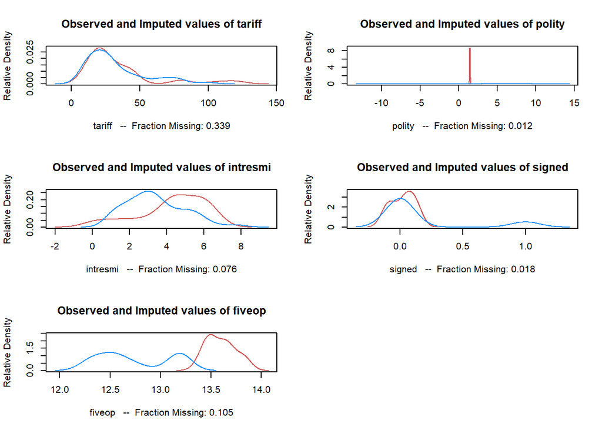

```r
plot(a.out.time) # overall basic Imputation information plot
summary(a.out.time)
```

- Note how the imputed values fit original observations better.

We can add leads and lags to calculate the imputation (along with trends specific to each cross-sectional unit):

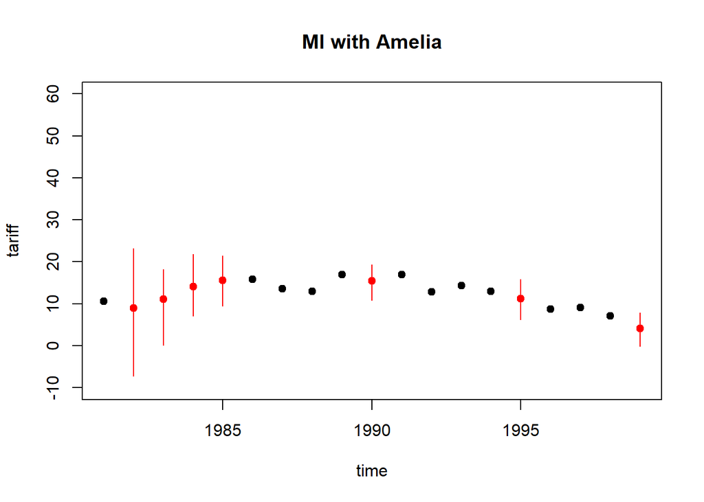

```r
set.seed(140)
a.out2 <- amelia(freetrade, ts = "year", cs = "country", lags = "tariff",
                 leads = "tariff", intercs = TRUE, polytime = 2, p2s = 0)
tscsPlot(a.out2, cs = "Malaysia", main = "MI with Amelia",
         var = "tariff", ylim = c(-10, 60))
```

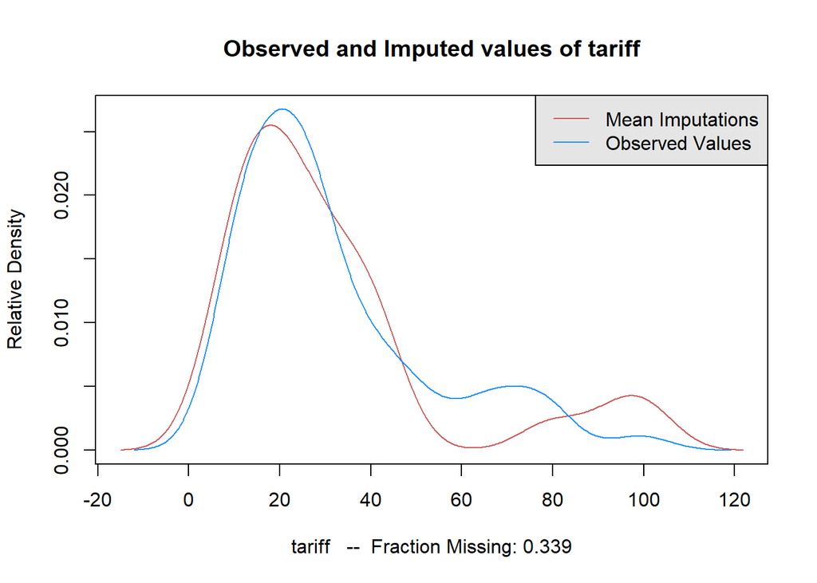

```r
compare.density(a.out2, var = "tariff") #not specific to Malaysia
```

```
##
## Amelia output with 5 imputed datasets.
## Return code:  1
## Message:  Normal EM convergence.
##
## Chain Lengths:
## --------------
## Imputation 1:  802
## Imputation 2:  1304
## Imputation 3:  681
## Imputation 4:  295
## Imputation 5:  496
##
## Rows after Listwise Deletion:  96
## Rows after Imputation:  171
## Patterns of missingness in the data:  8
##
## Fraction Missing for original variables:
## -----------------------------------------
##
##          Fraction Missing
## year           0.00000000
## country        0.00000000
## tariff         0.33918129
## polity         0.01169591
## pop            0.00000000
## gdp.pc         0.00000000
## intresmi       0.07602339
## signed         0.01754386
## fiveop         0.10526316
## usheg          0.00000000
```

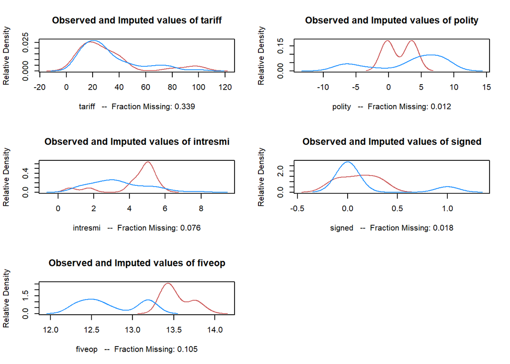

```r
plot(a.out2) # overall basic Imputation information plot
summary(a.out2)
```

- Calculation time for the last imputation task increases considerably.

Additional MI approaches (using prior information, etc.) and evaluation procedures can be observed from `Amelia` vignette:

https://cran.r-project.org/web/packages/Amelia/vignettes/amelia.pdf